# TP n° 2 : $k$-plus proches voisins, analyse discriminante linéaire et régression logistique

*Thomas KOCH*

*Information :* *Les réponses textuelles aux questions posées seront sous la forme suivante :*

> Réponse à la question

## - Rappels de classification -

### Génération artificielle de données

On considère dans cette partie des observations décrites en deux dimensions (afin de pouvoir les visualiser facilement) à savoir $p = 2$ dans le formalisme ci-dessus. On reprend en partie les jeux de données artificiels du TP sur le perceptron, avec des modifications sur les valeurs des étiquettes uniquement.

#### Question 1 : Etudions les fonctions `rand_bi_gauss`, `rand_tri_gauss`, `rand_clown` et `rand_checkers`

```python
###############################################################################
#               Import part
###############################################################################
import numpy as np
import matplotlib.pyplot as plt
from matplotlib import cm
from matplotlib import rc
from sklearn import neighbors, model_selection, datasets, svm, metrics
import seaborn as sns
from matplotlib.colors import ListedColormap
from mpl_toolkits.mplot3d import Axes3D


from sklearn.model_selection import train_test_split
from sklearn.metrics import confusion_matrix

from sklearn.utils.multiclass import unique_labels
```

```python
###############################################################################
#               Data Generation
###############################################################################


def rand_gauss(n=100, mu=[1, 1], sigmas=[0.1, 0.1]):
    """ Sample n points from a Gaussian variable with center mu,
    and std deviation sigma
    """
    d = len(mu)
    res = np.random.randn(n, d)
    return np.array(res * sigmas + mu)


def rand_bi_gauss(n1=100, n2=100, mu1=[1, 1], mu2=[-1, -1], sigmas1=[0.1, 0.1],
                  sigmas2=[0.1, 0.1]):
    """ Sample n1 and n2 points from two Gaussian variables centered in mu1,
    mu2, with respective std deviations sigma1 and sigma2
    """
    ex1 = rand_gauss(n1, mu1, sigmas1)
    ex2 = rand_gauss(n2, mu2, sigmas2)
    y = np.hstack([np.ones(n1), -1 * np.ones(n2)])
    X = np.vstack([ex1, ex2])
    ind = np.random.permutation(n1 + n2)
    return X[ind, :], y[ind]


def rand_tri_gauss(n1=100, n2=100, n3=100, mu1=[1, 1],
                   mu2=[-1, -1], mu3=[1, -1], sigma1=[0.1, 0.1],
                   sigma2=[0.1, 0.1], sigma3=[0.1, 0.1]):
    """ Sample n1, n2 and n3 points from three Gaussian variables centered in mu1,
    mu2 and mu3 with std deviation sigma1, sigma2 and sigma3
    """
    ex1 = rand_gauss(n1, mu1, sigma1)
    ex2 = rand_gauss(n2, mu2, sigma2)
    ex3 = rand_gauss(n3, mu3, sigma3)
    X = np.vstack([ex1, ex2, ex3])
    y = np.hstack([np.ones(n1), 2. * np.ones(n2), 3 * np.ones(n2)])

    ind = np.random.permutation(n1 + n2 + n3)
    np.random.shuffle(ind)
    return X[ind, :], y[ind]


def rand_clown(n1=100, n2=100, sigma1=1, sigma2=2):
    """ Sample a dataset clown  with
    n1 points and noise std deviation sigma1 for the first class, and
    n2 points and noise std deviation sigma2 for the second one
    """
    x0 = np.random.randn(n1, 1)
    x1 = x0 * x0 + sigma1 * np.random.randn(n1, 1)
    x2 = np.hstack([sigma2 * np.random.randn(n2, 1),
                    sigma2 * np.random.randn(n2, 1) + 2.])
    X = np.vstack([np.hstack([x0, x1]), x2])
    y = np.hstack([np.ones(n1), -1 * np.ones(n2)])
    ind = np.random.permutation(n1 + n2)
    return X[ind, :], y[ind]


def rand_checkers(n1=100, n2=100, sigma=0.1):
    """ Sample n1 and n2 points from a noisy checker"""
    nbp = int(np.floor(n1 / 8))
    nbn = int(np.floor(n2 / 8))
    xapp = np.reshape(np.random.rand((nbp + nbn) * 16), [(nbp + nbn) * 8, 2])
    yapp = np.ones((nbp + nbn) * 8)
    idx = 0
    for i in range(-2, 2):
        for j in range(-2, 2):
            if (((i + j) % 2) == 0):
                nb = nbp
            else:
                nb = nbn
                yapp[idx:(idx + nb)] = [(i + j) % 3 + 1] * nb

            xapp[idx:(idx + nb), 0] = np.random.rand(nb)
            xapp[idx:(idx + nb), 0] += i + sigma * np.random.randn(nb)
            xapp[idx:(idx + nb), 1] = np.random.rand(nb)
            xapp[idx:(idx + nb), 1] += j + sigma * np.random.randn(nb)
            idx += nb

    ind = np.arange((nbp + nbn) * 8)
    np.random.shuffle(ind)
    res = np.hstack([xapp, yapp[:, np.newaxis]])
    return np.array(res[ind, :2]), np.array(res[ind, 2])
```

Que renvoient ces fonctions ? À quoi correspond la dernière colonne ?

> - La fonction `rand_bi_gauss` mélange aléatoirement 2 distributions gaussiennes de paramètres respectifs *(mu1, sigma1)* et *(mu2, sigma2)*. Ces paramètres sont en fait le couple *(moyenne, variance)* de chaque distribution. Le nombre de points généré pour chaque distribution est respectivement de *n1* et *n2*.
> - La fonction `rand_tri_gauss` mélange aléatoirement 3 distributions gaussiennes selon le même principe que `rand_bi_gauss`.
> - La fonction `rand_clown` mélange aléatoirement 2 distributions :
>   - une parabolique de variance *sigma* ;
>   - une distribution de moyenne nulle ;
> - La fonction `rand_checkers` génère un damier de manière aléatoire.

Génération des données pour `rand_bi_gauss` :

```python
n1 = 100
n2 = 100
mu1 = [1., 1.]
mu2 = [-1., -1.]
sigmas1 = [0.9, 0.9]
sigmas2 = [0.9, 0.9]
X1, y1 = rand_bi_gauss(n1, n2, mu1, mu2, sigmas1, sigmas2)

X1.shape, y1.shape
```

```
((200, 2), (200,))
```

Génération des données pour `rand_tri_gauss` :

```python
n1=50
n2=50
n3=50
mu1=[1., 1.]
mu2=[-1., -1.]
mu3 = [1., -1.]
sigma1=[0.9, 0.9]
sigma2=[0.9, 0.9]
sigma3=[0.9, 0.9]
X2, y2 = rand_tri_gauss(n1, n2, n3, mu1, mu2, mu3, sigma1, sigma2, sigma3)

X2.shape, y2.shape
```

```
((150, 2), (150,))
```

Génération des données pour `rand_clown` :

```python
n1 = 100
n2 = 100
sigmas1 = 0.1
sigmas2 = 0.2
X3, y3 = rand_clown(n1, n2, sigmas1, sigmas2)

X3.shape, y3.shape
```

```
((200, 2), (200,))
```

Génération des données pour `rand_checkers` :

```python
n1 = 150
n2 = 150
sigma = 0.9
X4, y4 = rand_checkers(n1, n2, sigma)

X4.shape, y4.shape
```

```
((288, 2), (288,))
```

#### Question 2 : Affichons les jeux de données générées avec chacune des fonctions à l'aide de la fonction `plot_2d`

```python
###############################################################################
#           Displaying labeled data
###############################################################################
symlist = ['o', 's', 'D', 'x', '+', '*', 'p', 'v', '-', '^']


def plot_2d(data, y=None, w=None, alpha_choice=1):
    """ Plot in 2D the dataset data, colors and symbols according to the
    class given by the vector y (if given); the separating hyperplan w can
    also be displayed if asked"""

    k = np.unique(y).shape[0]
    color_blind_list = sns.color_palette("colorblind", k)
    sns.set_palette(color_blind_list)
    if y is None:
        labs = [""]
        idxbyclass = [range(data.shape[0])]
    else:
        labs = np.unique(y)
        idxbyclass = [np.where(y == labs[i])[0] for i in range(len(labs))]

    for i in range(len(labs)):
        plt.scatter(data[idxbyclass[i], 0], data[idxbyclass[i], 1],
                    c=np.reshape(color_blind_list[i], (1, -1)), s=80,
                    marker=symlist[i])
    plt.ylim([np.min(data[:, 1]), np.max(data[:, 1])])
    plt.xlim([np.min(data[:, 0]), np.max(data[:, 0])])
    mx = np.min(data[:, 0])
    maxx = np.max(data[:, 0])
    if w is not None:
        plt.plot([mx, maxx], [mx * -w[1] / w[2] - w[0] / w[2],
                              maxx * -w[1] / w[2] - w[0] / w[2]],
                 "g", alpha=alpha_choice)
###############################################################################
```

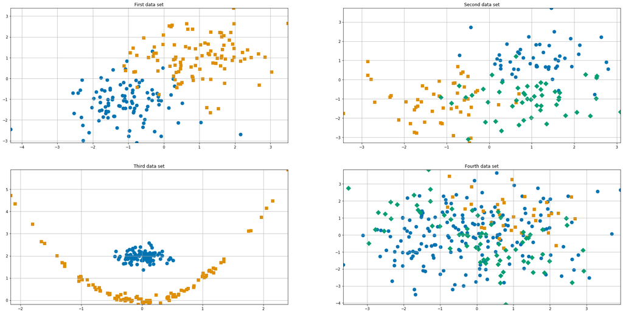

```python
plt.close("all")

plt.figure(1, figsize=(30, 15))

plt.subplot(221)
plt.title('First data set')
plot_2d(X1, y1)
plt.grid(True)

plt.subplot(222)
plt.title('Second data set')
plot_2d(X2, y2)
plt.grid(True)

plt.subplot(223)
plt.title('Third data set')
plot_2d(X3, y3)
plt.grid(True)

plt.subplot(224)
plt.title('Fourth data set')
plot_2d(X4, y4)
plt.grid(True)

plt.show()
```

> **Remarques :**
> - Les données des jeux 1 et 2 pourront facilement être séparées linéairement en appliquant par exemple une analyse discrimante linéaire (LDA en anglais, qu'on peut retrouver dans *sklearn*).
> - Les données du jeu 3 seront en revanche plus facilement séparables avec un classifieur k-nn.

## - La méthode des k-plus proches voisins -

### Approche intuitive

L’algorithme des $k$-plus proches voisins ($k-nn$ : pour $k-nearest neighbors$ en anglais) est un algorithme intuitif, aisément paramétrisable pour traiter un problème de classification avec un nombre quelconque d’étiquettes.  
Le principe de l’algorithme est particulièrement simple : pour chaque nouveau point $x$ on commence par déterminer l’ensemble de ses $k$-plus proches voisins parmi les points d’apprentissage que l’on note $Vk(x)$ (bien sûr on doit choisir $1 ≤ k ≤ n$ pour que cela ait un sens). La classe que l’on affecte au nouveau point $x$ est alors la classe majoritaire dans l’ensemble $Vk(x)$. Une illustration de la méthode est donnée en Figure 1 pour le cas de trois classes.

#### Question 3 : Proposons une version adaptée de cette méthode pour la régression, i.e., quand les observations $y$ sont à valeurs réelles : $Y = \mathbb{R}$.

> Une version adaptée de cette méthode pour la régression serait d'utiliser la moyenne des classes sur les plus proches voisins du point considéré.

### Approche formelle

Pour définir précisément la méthode, il faut commencer par choisir une distance $d : \mathbb{R}^p \times \mathbb{R}^p \mapsto \mathbb{R}$

Pour un nouveau point $x$, on définit alors l’ensemble de ses $k$-plus proches voisins $Vk(x)$ au sens de de cette distance.

#### Question 4 : Écrivons notre propre classe `KNNClassifier` avec les méthodes d’apprentissage `fit` et de classification `predict`

Nous choisirons une stratégie de traitement des ex aequo, c’est-à-dire des points avec la même distance ou le même nombre de points de chaque classe dans $Vk(x)$. Nous vérifierons la validité des résultats en les comparant à ceux de la classe `KNeighborsClassifier` de *scikit-learn* en utilisant le jeu de données #2. Nous porposerons notre propre méthode de comparaison (par exemple, en utilisant les observations d’indice pair pour le set d’apprentissage et celles d’indice impair pour le set de test).

Pour plus d’information sur les classes on peut consulter le lien suivant : http://docs.python.org/3/tutorial/classes.html.

```python
from sklearn.base import BaseEstimator, ClassifierMixin
from collections import Counter
from sklearn.metrics.pairwise import pairwise_distances

class KNNClassifier(BaseEstimator, ClassifierMixin):
#""" Homemade kNN classifier class """
    def __init__(self, n_neighbors=1):
        self.n_neighbors = n_neighbors

    def fit(self, X, y):
        self.X = X
        self.y = y
        return self

    def predict(self, X):
        dist =  pairwise_distances(X, self.X, 'euclidean')
        ind = np.argsort(dist, axis=1)
        y = np.zeros((X.shape[0],))

        for p in range(X.shape[0]):
            list_val = []
            for i in range(self.n_neighbors):
                #print(self.y[ind[0,i]])
                list_val.append(self.y[ind[p,i]])
            y[p] = Counter(list_val).most_common() [0][0]
        return y
```

> Testons simplement notre classifieur maison sur un petit jeu de données avant de passer à l'échelle

```python
classifier = KNNClassifier(n_neighbors=5)
classifier.fit(X2, y2)
#X0 = [[-1., -1.], [0., 0.]]
X0 = np.array([[-1., -1.], [0., 0.], [2., 2.], [2, -2]])
classifier.predict(X0)
```

```
array([2., 3., 1., 3.])
```

> Maintenant que notre classifieur semble fonctionner, nous allons, comme le suggère l'énoncé, utiliser les observations d'indice pair pour le set d'apprentissage et d'indice impair pour le set de test, puis nous comparerons les résultats de notre classifieur avec la fonction de `sklearn`

```python
classifier = KNNClassifier(n_neighbors=5)
classifier.fit(X2[::2], y2[::2])
classifier_predictions = classifier.predict(X2[1::2])
print(classifier_predictions)
```

```
[2. 3. 3. 3. 1. 1. 2. 1. 2. 2. 3. 2. 2. 2. 3. 3. 3. 1. 1. 3. 1. 3. 3. 3.
 1. 3. 2. 2. 1. 3. 1. 3. 3. 3. 1. 1. 3. 3. 1. 3. 2. 1. 2. 2. 1. 2. 1. 3.
 3. 3. 3. 3. 1. 2. 3. 3. 3. 2. 1. 1. 1. 2. 3. 1. 1. 2. 1. 2. 3. 3. 1. 2.
 1. 2. 1.]
```

```python
from sklearn.neighbors import KNeighborsClassifier

neigh2 = KNeighborsClassifier(n_neighbors=5)
neigh2.fit(X2[::2], y2[::2])
neigh2_predictions = neigh2.predict(X2[1::2])
print(neigh2_predictions)
```

```
[2. 3. 3. 3. 1. 1. 2. 1. 2. 2. 3. 2. 2. 2. 3. 3. 3. 1. 1. 3. 1. 3. 3. 3.
 1. 3. 2. 2. 1. 3. 1. 3. 3. 3. 1. 1. 3. 3. 1. 3. 2. 1. 2. 2. 1. 2. 1. 3.
 3. 3. 3. 3. 1. 2. 2. 3. 3. 2. 1. 1. 1. 2. 3. 1. 1. 2. 1. 2. 3. 3. 1. 2.
 1. 2. 1.]
```

```python
classifier_predictions == neigh2_predictions
```

```
array([ True,  True,  True,  True,  True,  True,  True,  True,  True,
        True,  True,  True,  True,  True,  True,  True,  True,  True,
        True,  True,  True,  True,  True,  True,  True,  True,  True,
        True,  True,  True,  True,  True,  True,  True,  True,  True,
        True,  True,  True,  True,  True,  True,  True,  True,  True,
        True,  True,  True,  True,  True,  True,  True,  True,  True,
       False,  True,  True,  True,  True,  True,  True,  True,  True,
        True,  True,  True,  True,  True,  True,  True,  True,  True,
        True,  True,  True])
```

> On retrouve donc quasiment les mêmes résultats entre notre algorithme et l'implémentation de `sklearn.neighbors`. Visualisons, par curiosité, les frontières définies.

```python
###############################################################################
#           Displaying tools for the Frontiere
###############################################################################


def frontiere(f, data, step=50, cmap_choice=cm.coolwarm, tiny=False):
    """ trace la frontiere pour la fonction de decision f"""
    xmin, xmax = data[:, 0].min() - 1., data[:, 0].max() + 1.
    ymin, ymax = data[:, 1].min() - 1., data[:, 1].max() + 1.
    xx, yy = np.meshgrid(np.arange(xmin, xmax, (xmax - xmin) * 1. / step),
                         np.arange(ymin, ymax, (ymax - ymin) * 1. / step))
    z = f(np.c_[xx.ravel(), yy.ravel()])
    z = z.reshape(xx.shape)
    plt.imshow(z, origin='lower', interpolation="nearest",
               extent=[xmin, xmax, ymin, ymax], cmap=cmap_choice)
    if tiny:
        plt.xticks([])
        plt.yticks([])
    else:
        plt.colorbar()


def frontiere_new(f, X, y, w=None, step=50, alpha_choice=1, aspect='auto', colorbar=True,
                  samples=True):
    """ trace la frontiere pour la fonction de decision f"""
    # construct cmap

    min_tot0 = np.min(X[:, 0])
    min_tot1 = np.min(X[:, 1])

    max_tot0 = np.max(X[:, 0])
    max_tot1 = np.max(X[:, 1])
    delta0 = (max_tot0 - min_tot0)
    delta1 = (max_tot1 - min_tot1)
    xx, yy = np.meshgrid(np.arange(min_tot0, max_tot0, delta0 / step),
                         np.arange(min_tot1, max_tot1, delta1 / step))
    z = np.array([f(vec.reshape(1, -1)) for vec in np.c_[xx.ravel(), yy.ravel()]])
    z = z.reshape(xx.shape)
    labels = np.unique(z)
    color_blind_list = sns.color_palette("colorblind", labels.shape[0])
    sns.set_palette(color_blind_list)
    my_cmap = ListedColormap(color_blind_list)
    plt.imshow(z, origin='lower', interpolation="mitchell", alpha=0.80,
               cmap=my_cmap, extent=[min_tot0, max_tot0, min_tot1, max_tot1], aspect='auto')
    if colorbar is True:
        ax = plt.gca()
        cbar = plt.colorbar(ticks=labels)
        cbar.ax.set_yticklabels(labels)

    labels = np.unique(y)
    k = np.unique(y).shape[0]
    color_blind_list = sns.color_palette("colorblind", k)
    sns.set_palette(color_blind_list)
    ax = plt.gca()
    if samples is True:
        for i, label in enumerate(y):
            label_num = np.where(labels == label)[0][0]
            plt.scatter([X[i, 0]], [X[i, 1]], c=[color_blind_list[label_num]],
                        s=80, marker=symlist[label_num])
    plt.xlim([min_tot0, max_tot0])
    plt.ylim([min_tot1, max_tot1])
    ax.get_yaxis().set_ticks([])
    ax.get_xaxis().set_ticks([])
    if w is not None:
        plt.plot([min_tot0, max_tot0],
                 [min_tot0 * -w[1] / w[2] - w[0] / w[2],
                  max_tot0 * -w[1] / w[2] - w[0] / w[2]],
                 "k", alpha=alpha_choice)
```

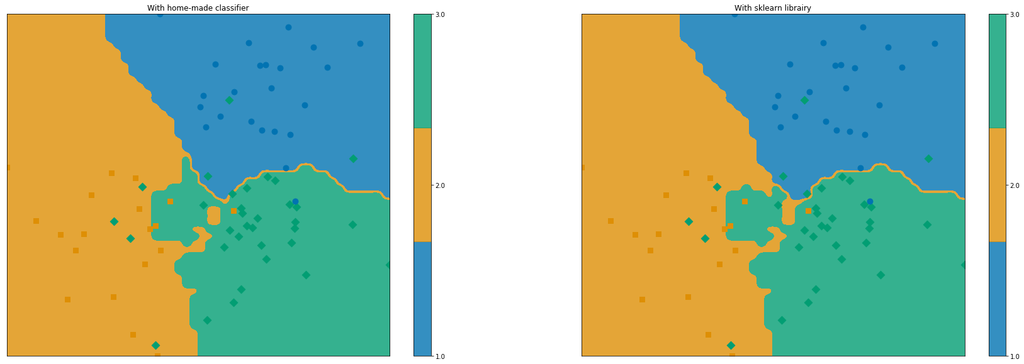

```python
plt.figure(figsize=(30,10))

plt.subplot(121)
plt.title("With home-made classifier")
def f_classifier(x):
    return classifier.predict(x)
frontiere_new(f_classifier, X2[1::2], y2[1::2])

plt.subplot(122)
plt.title("With sklearn librairy")
def f_neigh2(x):
    return neigh2.predict(x)
frontiere_new(f_neigh2, X2[1::2], y2[1::2])
```

> Il est intéressant de noter que les frontières sont quasiment identiques, mais pas exactement dans tous les détails comme le montrent les figures ci-dessus.

#### Question 5 : Faisons tourner sur les quatre exemples de jeux de données cet algorithme de classification, en utilisant la distance euclidienne classique $d(x, v) = ||x − v||_2$ et $k = 5$

Visualisons les règles de classification obtenues en utilisant la fonction `frontiere_new`.

> Nous utiliserons la même règle que précedemment pour entraîner et tester nos modèles.

```python
neigh1 = KNeighborsClassifier(n_neighbors=5)
neigh1.fit(X1[::2], y1[::2])
neigh1_predictions = neigh1.predict(X1[1::2])
print(neigh1_predictions)

neigh3 = KNeighborsClassifier(n_neighbors=5)
neigh3.fit(X3[::2], y3[::2])
neigh3_predictions = neigh3.predict(X3[1::2])
print(neigh3_predictions)

neigh4 = KNeighborsClassifier(n_neighbors=5)
neigh4.fit(X4[::2], y4[::2])
neigh4_predictions = neigh4.predict(X4[1::2])
print(neigh4_predictions)
```

```
[-1.  1. -1. -1. -1. -1. -1. -1.  1. -1.  1. -1.  1. -1.  1. -1. -1. -1.
  1.  1.  1. -1. -1. -1.  1.  1.  1.  1.  1.  1.  1. -1.  1.  1. -1. -1.
  1.  1.  1. -1. -1.  1.  1.  1.  1.  1.  1. -1.  1. -1.  1. -1.  1. -1.
  1. -1.  1. -1. -1.  1.  1. -1.  1.  1. -1.  1. -1. -1.  1.  1.  1.  1.
 -1.  1. -1.  1. -1.  1.  1. -1. -1.  1.  1.  1.  1.  1. -1.  1.  1.  1.
 -1.  1.  1.  1. -1.  1. -1.  1. -1.  1.]
[-1. -1. -1. -1. -1.  1. -1. -1. -1. -1.  1.  1. -1. -1.  1. -1. -1. -1.
 -1.  1.  1.  1.  1.  1. -1. -1. -1.  1. -1.  1. -1. -1.  1. -1.  1.  1.
 -1. -1. -1.  1.  1. -1. -1. -1. -1. -1.  1. -1. -1.  1. -1. -1. -1.  1.
  1. -1. -1.  1. -1.  1.  1. -1. -1. -1. -1.  1. -1.  1.  1. -1.  1. -1.
 -1.  1.  1.  1.  1.  1. -1.  1.  1.  1. -1.  1. -1.  1.  1. -1. -1.  1.
 -1. -1. -1.  1. -1.  1. -1.  1.  1. -1.]
[1. 1. 1. 1. 1. 1. 1. 2. 1. 1. 3. 1. 1. 1. 2. 1. 1. 1. 1. 1. 1. 1. 1. 1.
 1. 1. 1. 2. 1. 1. 3. 1. 1. 1. 1. 1. 1. 1. 1. 1. 1. 1. 2. 1. 1. 1. 1. 1.
 3. 1. 2. 1. 3. 1. 1. 1. 1. 1. 1. 1. 1. 1. 3. 1. 1. 1. 2. 1. 1. 1. 1. 1.
 1. 3. 3. 3. 1. 1. 1. 1. 1. 1. 1. 1. 1. 1. 3. 1. 1. 1. 2. 1. 3. 1. 1. 1.
 1. 1. 2. 1. 1. 1. 3. 1. 1. 3. 1. 1. 1. 2. 1. 1. 1. 1. 1. 1. 1. 1. 3. 3.
 1. 2. 1. 1. 3. 1. 2. 3. 3. 1. 1. 1. 1. 1. 1. 1. 1. 1. 1. 1. 1. 1. 1. 1.]
```

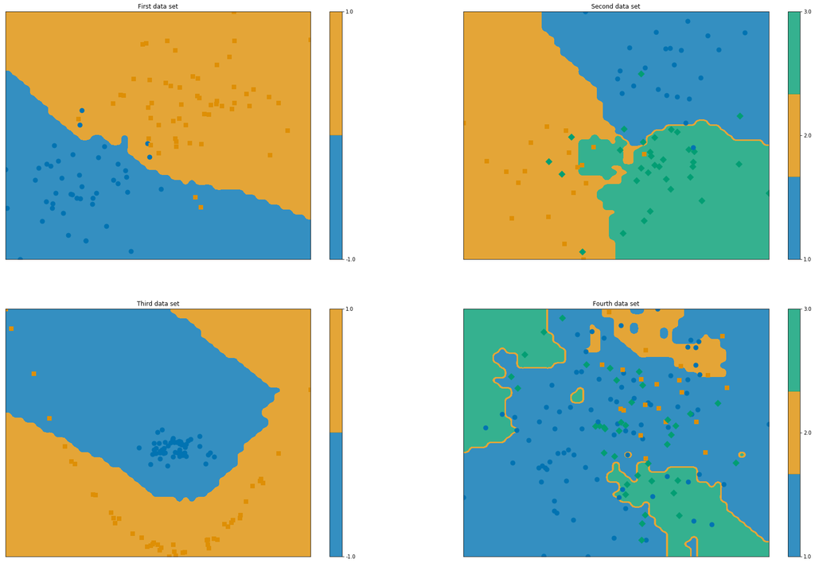

```python
plt.figure(figsize=(30, 20))

plt.subplot(221)
plt.title('First data set')
def f_neigh1(x):
        return neigh1.predict(x)
frontiere_new(f_neigh1, X1[1::2], y1[1::2])

plt.subplot(222)
plt.title('Second data set')
def f_neigh2(x):
        return neigh2.predict(x)
frontiere_new(f_neigh2, X2[1::2], y2[1::2])

plt.subplot(223)
plt.title('Third data set')
def f_neigh3(x):
        return neigh3.predict(x)
frontiere_new(f_neigh3, X3[1::2], y3[1::2])

plt.subplot(224)
plt.title('Fourth data set')
def f_neigh4(x):
        return neigh4.predict(x)
frontiere_new(f_neigh4, X4[1::2], y4[1::2])
```

## Question 6 : Pour les observations d’indice pairs du jeu de données #2, faisons varier le nombre k de voisins pris en compte : $k = 1, 2, . . . , n$

Que devient la méthode dans le cas extrême où $k = 1$ ? $k = n$ ? Afficher ces cas sur les données étudiées en utilisant la fonction `frontiere_new` et présentez les dans une forme facilement lisible. Dans quels cas la frontière est-elle complexe ? simple ?

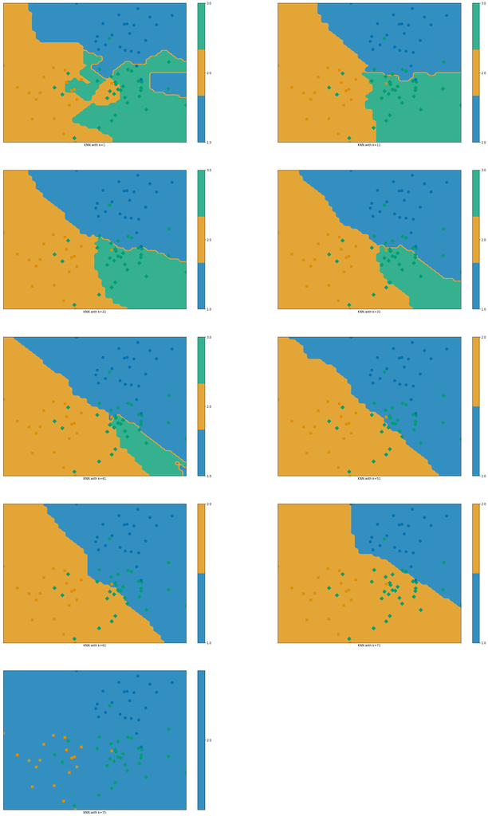

```python
plt.figure(3, figsize=(30, 80))

i = 0
for n_neighbors in range(1,72,10): # il faut n_neighbors <= n_samples,  avec n_samples = 75 dans notre cas
    i = i + 1
    knn_classifier = KNeighborsClassifier(n_neighbors = n_neighbors)
    knn_classifier.fit(X2[::2],y2[::2])
    plt.subplot(8, 2, i)
    plt.xlabel('KNN with k=%d' % n_neighbors)
    def f_knn(x):
        return knn_classifier.predict(x)
    frontiere_new(f_knn, X2[1::2], y2[1::2])
    if n_neighbors == 71 :
        n_neighbors = 75
        i = i + 1
        knn_classifier = KNeighborsClassifier(n_neighbors = n_neighbors)
        knn_classifier.fit(X2[::2],y2[::2])
        plt.subplot(8, 2, i)
        plt.xlabel('KNN with k=%d' % n_neighbors)
        def f_knn(x):
            return knn_classifier.predict(x)
        frontiere_new(f_knn, X2[1::2], y2[1::2])

plt.show()
```

#### Question 7 : Pondération des poids du $j^{ième}$ voisin

Le poids attribué au $j^{ième}$ voisin est : $$ w_{j}=\ \exp{(-\ \frac{d_{j}^{2}}{h})} $$

Implémentez cette variante dans `scikit-learn` en passant le paramètre `weights` au constructeur de `KNeighborsClassifier`. (Une autre possibilité consiste à pondérer les variable et non seulement les observations, on le regarde pas ici.) On pourra s’inspirer de `_weight_func` de la partie test de scikit-learn : https://github.com/scikit-learn/scikit-learn/blob/master/sklearn/neighbors/tests/test_neighbors.py

Pour tester l’impact du choix de $h$ sur les frontières de classification, visualisez les règles de classification pour $k = 7$ et $h = 10^j$ avec $j = −2, −1, 0, 1, 2 ;$

Utilisez les observations d’indice pair du jeux de données #2 pour l’entrainement du classifieur (Vous pouvez utiliser la fonction `frontiere_new`.)

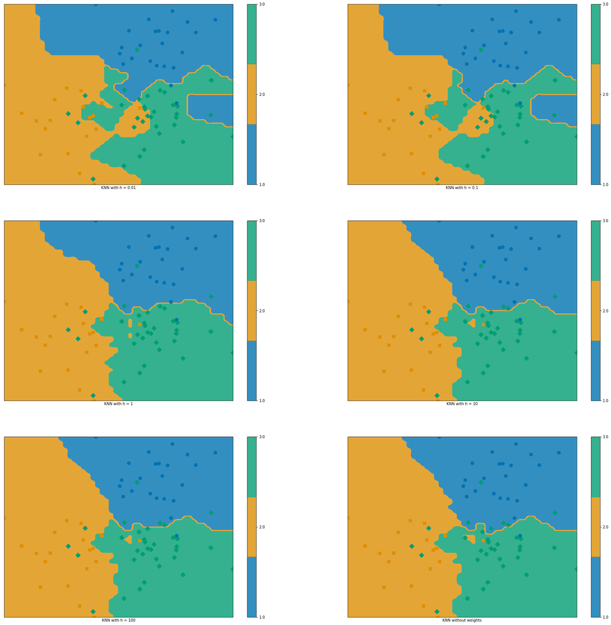

```python
def weights(dist):
            h = 10**j
            w = np.exp(-dist**2/h)
            return w

def f_knn(x):
    return knn.predict(x)

fig = plt.figure(figsize=(30, 30))

j = -2
knn = KNeighborsClassifier(n_neighbors = 7, weights = weights)
knn.fit(X2[::2], y2[::2])
plt.subplot(3,2,1)
plt.xlabel('KNN with h = 0.01')
frontiere_new(f_knn, X2[1::2], y2[1::2])

j = -1
knn = KNeighborsClassifier(n_neighbors = 7, weights = weights)
knn.fit(X2[::2], y2[::2])
plt.subplot(3,2,2)
plt.xlabel('KNN with h = 0.1')
frontiere_new(f_knn, X2[1::2], y2[1::2])

j = 0
knn = KNeighborsClassifier(n_neighbors = 7, weights = weights)
knn.fit(X2[::2], y2[::2])
plt.subplot(3,2,3)
plt.xlabel('KNN with h = 1')
frontiere_new(f_knn, X2[1::2], y2[1::2])

j = 1
knn = KNeighborsClassifier(n_neighbors = 7, weights = weights)
knn.fit(X2[::2], y2[::2])
plt.subplot(3,2,4)
plt.xlabel('KNN with h = 10')
frontiere_new(f_knn, X2[1::2], y2[1::2])

j = 2
knn = KNeighborsClassifier(n_neighbors = 7, weights = weights)
knn.fit(X2[::2], y2[::2])
plt.subplot(3,2,5)
plt.xlabel('KNN with h = 100')
frontiere_new(f_knn, X2[1::2], y2[1::2])

# without weights
knn = KNeighborsClassifier(n_neighbors = 7, weights = None )
knn.fit(X2[::2], y2[::2])
plt.subplot(3,2,6)
plt.xlabel('KNN without weights')
frontiere_new(f_knn, X2[1::2], y2[1::2])
```

#### Question 8 : Taux d'erreur sur les données d'apprentissage et les données de test

Quel est le taux d’erreur sur les mêmes données d’apprentissage (i.e., la proportion d’erreur faite par le classifieur) lorsque $k = 1$ ? et sur des données de test (les observations d’indice pair) ?

```python
knn = KNeighborsClassifier(n_neighbors = 1)
knn.fit(X2[::2], y2[::2])
error_rate_train = (1 - knn.score(X2[::2], y2[::2]))*100
print(f"\n Le taux d'erreur sur les données d'apprentissage est de {round(error_rate_train,2)} %")
```

```
 Le taux d'erreur sur les données d'apprentissage est de 0.0 %
```

> Nous avons ici surentraîné nos données en choisissant clairement de définir le point à classifier comme étant lui même son plus proche voisi. On se trouve donc dans le cas d'un modèle complexe avec une frontière de classification en rapport et qui nus permet d'être très bon sur nos données d'apprentissage. Il conviendrait donc d'enlever un peu de complexité à notre modèle pour éviter cet "overfitting".

```python
knn = KNeighborsClassifier(n_neighbors = 1)
knn.fit(X2[::2], y2[::2])
error_rate_test = (1 - knn.score(X2[1::2], y2[1::2]))*100
print(f"\n Le taux d'erreur sur les données de test est de {round(error_rate_test,2)} %")
```

```
 Le taux d'erreur sur les données de test est de 21.33 %
```

> Ce taux d'erreur n'est pas si mauvais que cela dans l'absolu mais pourrait très certainement être amélioré et c'est ce que nous allons étudier dans la question suivante.

#### Question 9 : Taux d'erreur en fonction de k

Pour le jeu de données #4, en utilisant les observations d’indice pair pour l’apprentissage et les observations d’indice impair pour le test, tracez le taux d’erreur en fonction de $k$ pour $k = 1, 2, ..., 50$. Vous pourrez utiliser la classe fournie `ErrorCurve`.

```python
###############################################################################
#               Algorithms and functions
###############################################################################

class ErrorCurve(object):
    def __init__(self, k_range=None, weights='uniform'):
        if k_range is None:
            k_range = list(range(1, 6))
        self.k_range = k_range
        self.weights = weights

    def fit_curve(self, X, y, Xtest, ytest):
        def error_func(k):
            knn = neighbors.KNeighborsClassifier(n_neighbors=k,
                                                 weights=self.weights)
            knn.fit(X, y)
            error = np.mean(knn.predict(Xtest) != ytest)
            return error

        errors = list(map(error_func, self.k_range))
        self.errors = np.array(errors)
        self.y = y

    def plot(self, marker='o', maketitle=True, **kwargs):
        plt.plot(self.k_range, self.errors, marker=marker, **kwargs)
        plt.xlabel("K")
        plt.ylabel("Test error")
        if maketitle:
            plt.title("number of training points : %d" % len(self.y))
```

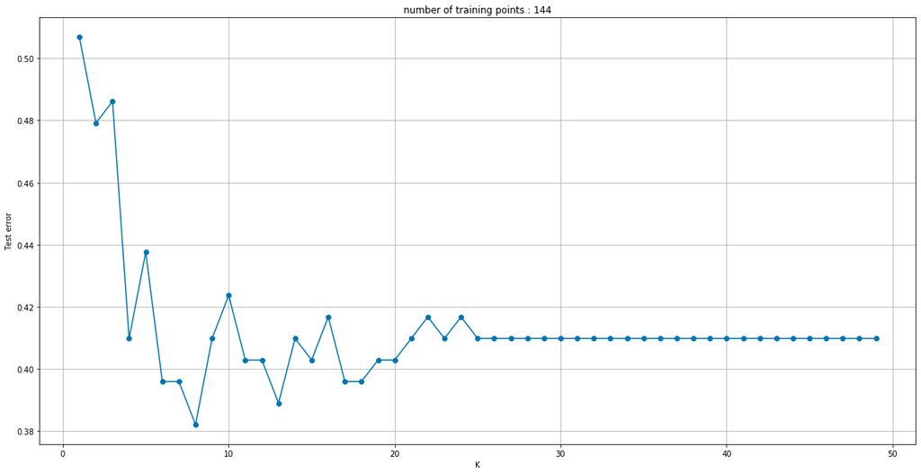

```python
plt.figure(figsize=(20, 10))
X4_error = ErrorCurve(k_range=list(range(1,50)))
X4_error.fit_curve(X4[::2],y4[::2], X4[1::2],y4[1::2])
X4_error.plot(marker='o', maketitle=True)
plt.grid(True)
```

> L'analyse sur ce jeu de données n'est pas très évidente. On remarque en effet qu'il y a plusieurs moyens de minimiser le risque sur cet exemple mais difficile d'en tirer une conclusion ferme.  
> Voyons ce que nous pourrions obtenir avec le jeu de données #2.

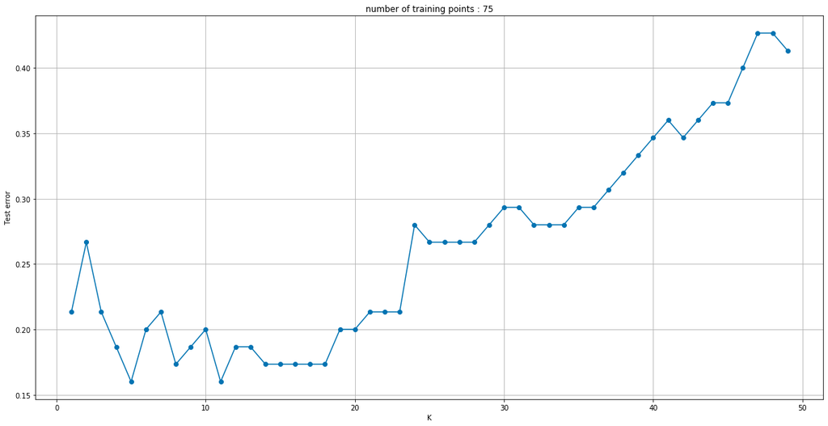

```python
plt.figure(figsize=(20, 10))
X2_error = ErrorCurve(k_range=list(range(1,50)))
X2_error.fit_curve(X2[::2], y2[::2], X2[1::2], y2[1::2])
X2_error.plot(marker='o', maketitle=True)
plt.grid(True)
```

> Sur ce jeu de données, on peut voir que le risque est contenu pour $k$ aux alentours de 10.

#### Question 10 : Taux d'erreur en fonction de k et de l'échantillonnage des données #4

Tracez les différentes courbes d’erreur en fonction du paramètre $k = (1, 2, . . . , 50)$ sur le jeu de données #4, pour des nombres d’échantillons d’entrainement $n$ prenant les valeurs 100, 200, 500 à 1000. Cette fois, tirez l’ensemble d’apprentissage et l’ensemble de test indépendamment et de même taille. Quelle est la meilleure valeur de $k$ ? Est-ce la même pour les différents datasets ? Vous pourrez utiliser la classe fournie `ErrorCurve`. Pour $n = 1000$ visualisez les données et la règle de décision sur le même graphique. (Vous pouvez utiliser la fonction `frontiere_new`).

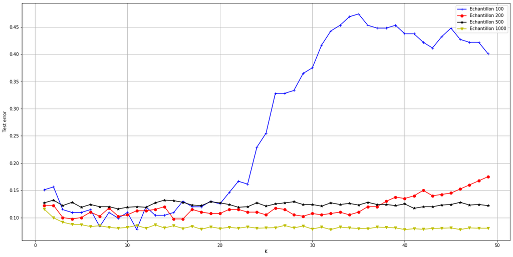

```python
n_samples=[100,200,500,1000]

m=['+','o','*','v']
c=['b','r','k','y']

sigma = 0.1
plt.figure(4, figsize=(20, 10))

for iteration, n_sample in enumerate(n_samples):
    label = 'Echantillon ' +str(n_sample)

    n1 = n_sample
    n2 = n_sample

    X_train, y_train = rand_checkers(n1, n2, sigma)
    X_test, y_test = rand_checkers(n1, n2, sigma)

    X4_error = ErrorCurve(k_range=list(range(1,50)))
    X4_error.fit_curve(X_train, y_train, X_test, y_test)
    marker_ = m[iteration]
    color_ = c[iteration]

    X4_error.plot(marker = marker_, color=color_, label=label, maketitle=False)
    plt.grid(True)
    plt.legend()
```

> Observons, pour $n = 1000$, les données et la règle de décision sur le même graphique :

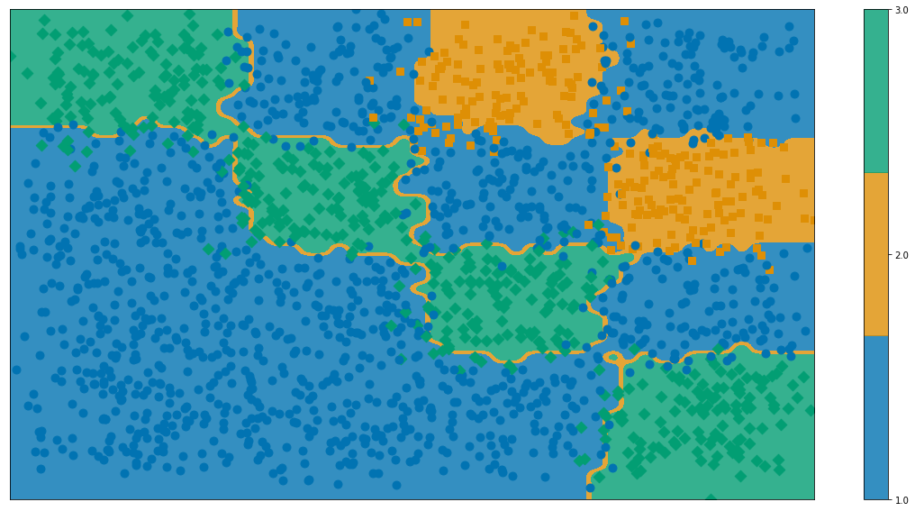

```python
knn = neighbors.KNeighborsClassifier(n_neighbors = 10)
knn.fit(X_train, y_train)
def f(x):
        return knn.predict(x)

fig = plt.figure(figsize=(20, 10))
frontiere_new(f, X_test, y_test)
```

#### Question 11 : Avantages et inconvénients de la méthode des plus proches voisins

A votre avis, quels sont les avantages et les inconvénients de la méthode des plus proches voisins : temps de calcul ? passage à l’échelle ? interprétabilité ?

> - La méthode des plus proches voisins à l'avantage d'être **facilement compréhensible et interprétable**.
> - Elle est en revanche **très gourmande en temps de calculs et mémoire** car il faut pour chaque point, mesurer la distance qui le sépare de ses voisins. On le vois d'ailleurs dans les exemples que nous traitons ici, les résultats mettent du temps avant de s'afficher. Il sera donc très coûteux d'utiliser les plus proches voisins pour des problèmes en grande dimension.

#### Question 12 : Etude de la base *DIGITS* de `scikit-learn`

Étudiez la base *DIGITS* de `scikit-learn`. On pourra se référer à http://scikit-learn.org/stable/_downloads/plot_digits_classification.py pour le chargement et la manipulation de la base de données. Pour de plus amples informations sur la nature de la classe `Bunch` (une sous-classe de dictionnaire, on se reportera à la documentation sur la classe `dict` : http://docs.python.org/2/library/stdtypes.html#mapping-types-dict.

Décrivez la nature et le format des données (précisément), affichez un exemple. Tracez l’histogramme pour des classes. Coupez l’échantillon en deux parties de même taille et utilisez la première partie pour l’apprentissage et la deuxième pour le test. Appliquez la méthode aux données issues de la base digits pour un choix de $k ≥ 1$ (e.g., $k = 30$) et indiquez le taux d’erreur.

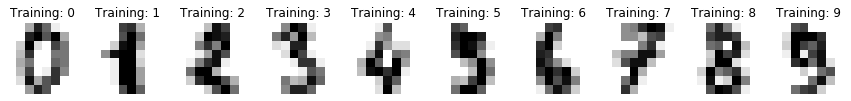

```python
# The digits dataset
digits = datasets.load_digits()

images_and_labels = list(zip(digits.images, digits.target))
plt.figure(figsize=(15,10))

for index, (image, label) in enumerate(images_and_labels[:10]):
    plt.subplot(1, 10, index + 1)
    plt.axis('off')
    plt.imshow(image, cmap=plt.cm.gray_r, interpolation='nearest')
    plt.title('Training: %i' % label)
```

> Les données sont donc des images pixélisées de chiffres allant de 0 à 9.

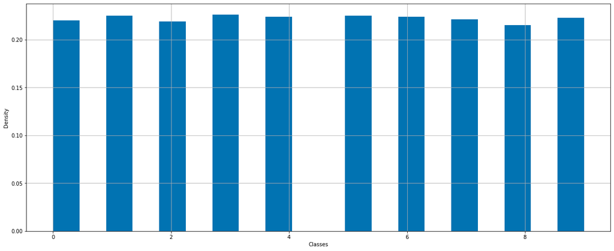

```python
labels = []
images = []

for index, (image, label) in enumerate(images_and_labels):
    labels.append(label)

plt.figure(figsize=(20, 8))
plt.hist(labels, bins = 20, density = True)
plt.xlabel("Classes")
plt.ylabel("Density")
plt.grid(True)
```

> Appliquons la calssification KNN à la base de données *DIGITS* à l'aide du code proposé en lien.

```python
# To apply a classifier on this data, we need to flatten the image, to
# turn the data in a (samples, feature) matrix:
n_samples = len(digits.images)
data = digits.images.reshape((n_samples, -1))

# Create a classifier: a KNN classifier
classifier = neighbors.KNeighborsClassifier(n_neighbors=30)

# We learn the digits on the first half of the digits
classifier.fit(data[:n_samples // 2], digits.target[:n_samples // 2])

# Now predict the value of the digit on the second half:
expected = digits.target[n_samples // 2:]
predicted = classifier.predict(data[n_samples // 2:])

print("Classification report for classifier %s:\n%s\n"
      % (classifier, metrics.classification_report(expected, predicted)))
```

```
Classification report for classifier KNeighborsClassifier(algorithm='auto', leaf_size=30, metric='minkowski',
                     metric_params=None, n_jobs=None, n_neighbors=30, p=2,
                     weights='uniform'):
              precision    recall  f1-score   support

           0       0.96      0.99      0.97        88
           1       0.93      0.90      0.92        91
           2       0.92      0.92      0.92        86
           3       0.83      0.89      0.86        91
           4       0.99      0.95      0.97        92
           5       0.89      0.93      0.91        91
           6       0.96      1.00      0.98        91
           7       0.93      0.99      0.96        89
           8       0.96      0.77      0.86        88
           9       0.91      0.91      0.91        92

    accuracy                           0.93       899
   macro avg       0.93      0.93      0.92       899
weighted avg       0.93      0.93      0.92       899
```

```python
print(f"\n Le taux d'erreur sur les prédictions est de {(round(100*(1 - metrics.accuracy_score(expected, predicted)),2))} %\n")
```

```
 Le taux d'erreur sur les prédictions est de 7.45 %
```

#### Question 13 : Matrice de confusion

Estimez la matrice de confusion $( \mathbb{P} \ \{Y = i, C_k(X) = j\})_{i, j}$ associée au classifieur $C_k$ ainsi obtenu et visualisez celle-ci. Pour la manipulation de telles matrices avec `scikit-learn`, on pourra consulter le lien suivant :  
http://scikit-learn.org/stable/auto_examples/model_selection/plot_confusion_matrix.html.

```python
print("Confusion matrix:\n%s" % metrics.confusion_matrix(expected, predicted))
```

```
Confusion matrix:
[[87  0  0  0  1  0  0  0  0  0]
 [ 0 82  5  1  0  1  0  0  0  2]
 [ 1  0 79  6  0  0  0  0  0  0]
 [ 0  0  0 81  0  3  0  4  1  2]
 [ 2  0  0  0 87  0  0  2  1  0]
 [ 0  0  0  0  0 85  3  0  0  3]
 [ 0  0  0  0  0  0 91  0  0  0]
 [ 0  0  1  0  0  0  0 88  0  0]
 [ 0  6  1  6  0  4  1  1 68  1]
 [ 1  0  0  4  0  2  0  0  1 84]]
```

```
Confusion matrix, without normalization
[[87  0  0  0  1  0  0  0  0  0]
 [ 0 82  5  1  0  1  0  0  0  2]
 [ 1  0 79  6  0  0  0  0  0  0]
 [ 0  0  0 81  0  3  0  4  1  2]
 [ 2  0  0  0 87  0  0  2  1  0]
 [ 0  0  0  0  0 85  3  0  0  3]
 [ 0  0  0  0  0  0 91  0  0  0]
 [ 0  0  1  0  0  0  0 88  0  0]
 [ 0  6  1  6  0  4  1  1 68  1]
 [ 1  0  0  4  0  2  0  0  1 84]]
```

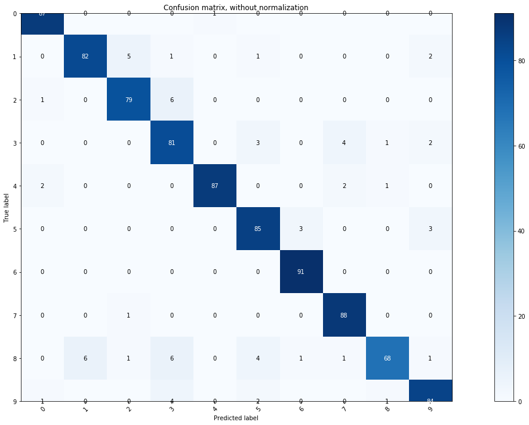

```python
def plot_confusion_matrix(y_true, y_pred, classes,
                          normalize=False,
                          title=None,
                          cmap=plt.cm.Blues):
    """
    This function prints and plots the confusion matrix.
    Normalization can be applied by setting `normalize=True`.
    """
    if not title:
        if normalize:
            title = 'Normalized confusion matrix'
        else:
            title = 'Confusion matrix, without normalization'

    # Compute confusion matrix
    cm = confusion_matrix(y_true, y_pred)
    # Only use the labels that appear in the data
    classes = classes[unique_labels(y_true, y_pred)]
    if normalize:
        cm = cm.astype('float') / cm.sum(axis=1)[:, np.newaxis]
        print("Normalized confusion matrix")
    else:
        print('Confusion matrix, without normalization')

    print(cm)

    fig, ax = plt.subplots(figsize=(20, 10))
    im = ax.imshow(cm, interpolation='nearest', cmap=cmap)
    ax.figure.colorbar(im, ax=ax)
    # We want to show all ticks...
    ax.set(xticks=np.arange(cm.shape[1]),
           yticks=np.arange(cm.shape[0]),
           # ... and label them with the respective list entries
           xticklabels=classes, yticklabels=classes,
           title=title,
           ylabel='True label',
           xlabel='Predicted label')

    # Rotate the tick labels and set their alignment.
    plt.setp(ax.get_xticklabels(), rotation=45, ha="right",
             rotation_mode="anchor")

    # Loop over data dimensions and create text annotations.
    fmt = '.2f' if normalize else 'd'
    thresh = cm.max() / 2.
    for i in range(cm.shape[0]):
        for j in range(cm.shape[1]):
            ax.text(j, i, format(cm[i, j], fmt),
                    ha="center", va="center",
                    color="white" if cm[i, j] > thresh else "black")
    fig.tight_layout()
    return ax

class_names = digits.target_names
plot_confusion_matrix(expected, predicted, classes=class_names,
                      title='Confusion matrix, without normalization')

plt.show()
```

```
Normalized confusion matrix
[[0.98863636 0.         0.         0.         0.01136364 0.
  0.         0.         0.         0.        ]
 [0.         0.9010989  0.05494505 0.01098901 0.         0.01098901
  0.         0.         0.         0.02197802]
 [0.01162791 0.         0.91860465 0.06976744 0.         0.
  0.         0.         0.         0.        ]
 [0.         0.         0.         0.89010989 0.         0.03296703
  0.         0.04395604 0.01098901 0.02197802]
 [0.02173913 0.         0.         0.         0.94565217 0.
  0.         0.02173913 0.01086957 0.        ]
 [0.         0.         0.         0.         0.         0.93406593
  0.03296703 0.         0.         0.03296703]
 [0.         0.         0.         0.         0.         0.
  1.         0.         0.         0.        ]
 [0.         0.         0.01123596 0.         0.         0.
  0.         0.98876404 0.         0.        ]
 [0.         0.06818182 0.01136364 0.06818182 0.         0.04545455
  0.01136364 0.01136364 0.77272727 0.01136364]
 [0.01086957 0.         0.         0.04347826 0.         0.02173913
  0.         0.         0.01086957 0.91304348]]
```

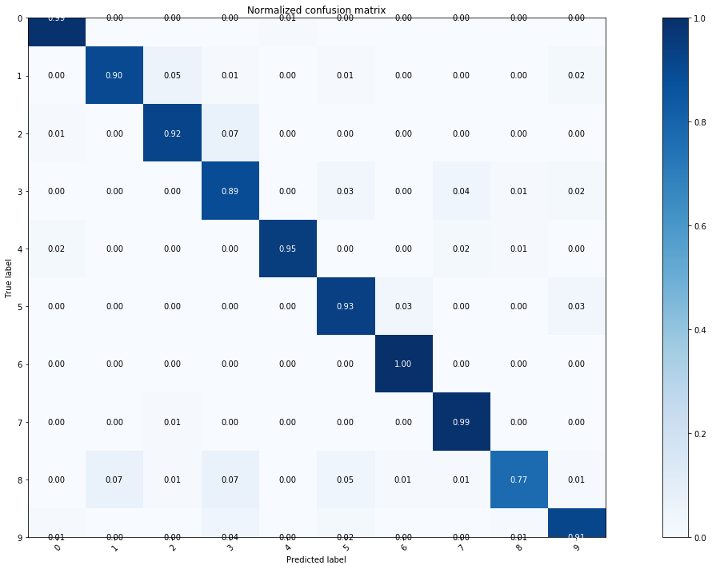

```python
# Plot normalized confusion matrix
plot_confusion_matrix(expected, predicted, classes=class_names, normalize=True,
                      title='Normalized confusion matrix')
```

#### Question 14 : Choix de $k$ par la méthode de validation croisée

Proposez une méthode pour choisir $k$ et mettez-la en œuvre. Vous pourrez utiliser la classe fournie `LOOCurve`. En utilisant toutes les données, tracez la courbe du taux d’erreur *leave-one-out* pour $k =\ 1,\ 6,\ 11,\ 16,\ 21,\ 26,\ 31,\ 36,\ 41,\ 46,\ 100,\ 200$

```python
class LOOCurve(object):
    """Leave-One-Out (LOO) curve"""
    def __init__(self, k_range=None, weights='uniform'):
        if k_range is None:
            k_range = list(range(1, 6))
        self.k_range = k_range
        self.weights = weights

    def fit_curve(self, X, y, n_iter=200, random_state=1):
        def score_func(k):
            n_samples = len(X)
            # Selon la verson de scikit-learn : shuffleSplit prend en argument
            # 'niter ' ou niterations'. De plus, l'argument test_size peut ne
            # pas etre reconnu. Il est recommande de consulter
            # help(model_selection.ShuffleSplit) pour connaitre la liste
            # des arguments reconnus par votre version de sickitlearn.
            loo = model_selection.ShuffleSplit(n_iter,
                                                test_size=1,
                                                train_size=n_samples-1,
                                                random_state=random_state)
            knn = neighbors.KNeighborsClassifier(n_neighbors=k,
                                                 weights=self.weights)
            scores = model_selection.cross_val_score(estimator=knn,
                                                      X=X, y=y,
                                                      cv=loo)
            return np.mean(scores)

        scores = list(map(score_func, self.k_range))
        self.cv_scores = np.array(scores)
        self.y = y

    def plot(self, marker='o', maketitle=True, **kwargs):
        plt.plot(self.k_range, self.cv_scores, marker=marker, **kwargs)
        plt.xlabel("K")
        plt.ylabel("Leave One Out Score (1-error rate)")
        if maketitle:
            plt.title("number of training points : %d" % (len(self.y) - 1))
```

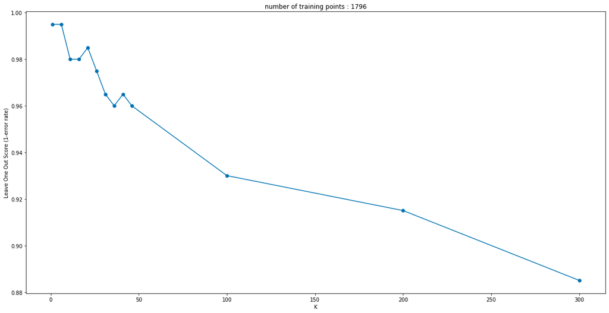

```python
k_range = [1,6,11,16,21,26,31,36,41,46,100,200,300]

CV_digits = LOOCurve(k_range = k_range)
CV_digits.fit_curve(data, digits.target)
plt.figure(figsize=(20,10))
CV_digits.plot()
```

> La validation croisée est une bonne méthode pour trouver les hyperparamètres optimaux. Nous avons affiché ci-dessus le score moyen testé sur tous les folds pour chaque k. Nous en déduisons donc que le meilleur score (et donc le taux d'erreurs le plus faible) est obtenu pour $k = 1$.

## - Analyse Discriminante Linéaire -

Le nom anglais est *Linear Discirmiant Analysis (LDA)*. Il est préférable de se reporter à cette dénomination en vue de trouver de l’aide en ligne pour la partie numérique. Attention toutefois à ne pas confondre avec Latent Dirichlet Allocation qui est un modèle statistique hiérarchique pour données catégorielles et qui n’a pas de lien avec l’Analyse Discriminante Linéaire.

### Aspect thérorique

#### Question 15 : Probabilités à posteriori

En utilisant la formule de Bayes donner la formule des probabilités a posteriori : $\mathbb{P}\{Y = +1 | X = x\},\ \mathbb{P}\{Y = −1 | X = x\}$, comme fonctions de $f_+$, $f_−$ et $π_+$.

> **Démonstration :** La formule de Bayes nous dit : $$ \mathbb{P} \{ Y = +1 | X = x \}\ =\ \frac{\mathbb{P} \{ X | Y = +1 \} \ \mathbb{P} \{ Y = +1 \} }{\mathbb{P} \{X\}} $$ et, $$ \mathbb{P} \{ Y = -1 | X = x \}\ =\ \frac{\mathbb{P} \{ X | Y = -1 \} \ \mathbb{P} \{ Y = -1 \} }{\mathbb{P} \{X\}} $$ De plus, la formule des probabilités totales nous donne : $$ \mathbb{P}\{ X \} \ = \ \mathbb{P}\{ X | Y = +1 \} \ \mathbb{P} \{ Y = +1 \} \ + \ \mathbb{P}\{X | Y = -1 \} \ \mathbb{P} \{ Y = -1 \} $$ D'où les résultats : $$ \mathbb{P}\{ Y = +1 | X = x \} \ = \ \frac { \pi_{+}f_{+} }{ \pi_{+}f_{+} + \pi_{-}f_{-}} \ \ \ \ \text{et} \ \ \ \ \mathbb{P}\{ Y = -1 | X = x \} \ = \ \frac { \pi_{-}f_{-} }{ \pi_{+}f_{+} + \pi_{-}f_{-}} $$

#### Question 17 : Justification du choix du classifieur

> Si la classe est égale à 1 alors cela signifie que la probabilité a posteriori de la classe en question est supèrieure à l'autre classe d'où $$\log(\frac{\mathbb{P}\{Y = +1 | X = x \}}{\mathbb{P}\{ Y =- 1 | X = x \}}) \ > \ 1$$ alors d'après Question 16 $$ x^{T} \ \Sigma^{-1}(\mu{+}-\mu{-}) -\frac{1}{2} \mu^{T}{+} \ \Sigma^{-1}\mu{+}\frac{1}{2} \mu^{T}{-} \ \Sigma^{-1}\mu{-} - \log(1-\frac{m}{n}) + \log(\frac{m}{n}) \ > \ 0$$ d'où $$x^{T} \ \Sigma^{-1}(\mu{+}-\mu{-}) \ > \ \frac{1}{2} \mu^{T}{+} \ \Sigma^{-1}\mu{+} \frac{1}{2} \mu^{T}{-} \ \Sigma^{-1}\mu{-} + \log(1-\frac{m}{n}) - \log(\frac{m}{n}) $$ Et on peut suivre le même raisonnement pour la classe égale à -1.

### Mise en oeuvre

#### Question 18 : LDAClassifier maison

Écrivez votre propre classe `LDAClassifier` avec les méthodes d’apprentissage `fit` et de classification `predic`.

```python
class LDAClassifier(BaseEstimator, ClassifierMixin):
##### Homemade LDA classifier class #####

    def fit(self, X, y):
        Xp = X[y == 1, :]
        Xn = X[y == -1, :]
        Xp_0 = Xp[:,0]
        Xp_1 = Xp[:,1]

        n = len(X)
        m = len(Xp)

        # mu+ and mu-
        meanp_0 = np.mean(Xp_0)
        meanp_1 = np.mean(Xp_1)
        meanp = np.array([meanp_0, meanp_1])
        Cov_p = np.cov(np.transpose(Xp))
        Xn_0 = Xn[:,0]
        Xn_1 = Xn[:,1]

        meann_0 = np.mean(Xn_0)
        meann_1 = np.mean(Xn_1)
        meann = np.array([meann_0,meann_1])
        Cov_n = np.cov(np.transpose(Xn))

        Cov_tot = (1/(n-2))*( (m-1)* Cov_p + (n-m-1)* Cov_n)
        inv_Cov_tot = np.linalg.inv(Cov_tot)

        a1 = np.dot(np.transpose(meanp),inv_Cov_tot)
        a2 = np.dot(np.transpose(meann),inv_Cov_tot)

        self.alpha = 0.5*(np.dot(a1,meanp)  - np.dot(a2,meann)) + np.log(1- m/n) - np.log(m/n)
        self.beta =  np.dot(inv_Cov_tot,meanp-meann)
        return self

    def predict(self, X):
        y_=[]
        for i in range(len(X)):
            Xpred = X[i]
            b = np.dot(np.transpose(Xpred), self.beta)
            if (b>self.alpha):
                Ypred = 1
            else:
                Ypred = -1
            y_.append(Ypred)
        return np.array(y_)
```

#### Question 19 : Comparaison entre notre classe et celle du module de `sklearn`

Importez le module `sklearn.discriminant_analysis` qui contient en particulier la classe `LinearDiscriminantAnalysis` qui nous servira dans la suite.

```
from sklearn.discriminant_analysis import LinearDiscriminantAnalysis
```

Vérifiez la validité des résultats obtenus avec votre méthode en les comparant à ceux de la classe `LinearDiscriminantAnalysis` de `scikit-learn` en utilisant un jeu de données simulé. Vous proposerez votre propre méthode de comparaison (l’échantillon d’apprentissage doit être petit et l’échantillon de validation doit être assez grand ; on considère par ailleurs que $m$ est différent de $n − m$, *i.e.*, les deux classes ne sont pas représentées par le même nombre d’échantillons observés). Indiquez les taux d’erreur de `LDAClassifier` et de `LinearDiscriminantAnalysis` et le nombre de cas où les prédictions coïncident. En utilisant votre classe `LDAClassifier`, visualisez la règle de classification. (Vous pouvez utiliser la fonction `frontiere_new`.)

```python
# Simulated sample with rand_bi_gauss
n1 = 50
n2 = 150
mu1 = [1., 1.]
mu2 = [-1., -1.]
sigmas1 = [0.9, 0.9]
sigmas2 = [0.9, 0.9]
X1, y1 = rand_bi_gauss(n1, n2, mu1, mu2, sigmas1, sigmas2)
```

```
Le taux d'erreur sur les données test avec notre méthode est de 4.67 %

Le taux d'erreur sur les données test avec la librairie sklearn est de 4.67 %
```

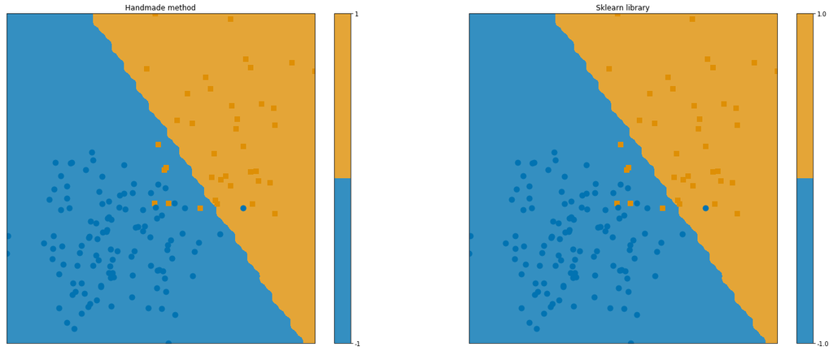

```python
LDAClassifier_test = LDAClassifier()
LDAClassifier_test.fit(X1[:50],y1[:50])
y1_LDAClassifier_pred = LDAClassifier_test.predict(X1[50:])

def f_LDAClassifier(x):
    return LDAClassifier_test.predict(x)

plt.figure(figsize=(25,10))
plt.subplot(121)
plt.title("Handmade method")
frontiere_new(f_LDAClassifier, X1[50:],y1[50:])
pred_error_rate = 1 - LDAClassifier_test.score(X1[50:],y1[50:])
print(f"Le taux d'erreur sur les données test avec notre méthode est de {round(100*pred_error_rate,2)} %\n")


######################################
from sklearn.discriminant_analysis import LinearDiscriminantAnalysis


LDA_sklearn_test = LinearDiscriminantAnalysis()
LDA_sklearn_test.fit(X1[:50],y1[:50])
y1_LDA_sklearn_pred = LDA_sklearn_test.predict(X1[50:])

def f_LDA_sklearn(x):
    return LDA_sklearn_test.predict(x)

plt.subplot(122)
plt.title("Sklearn library")
frontiere_new(f_LDA_sklearn, X1[50:],y1[50:])
pred_error_rate_sklearn = 1 - LDA_sklearn_test.score(X1[50:],y1[50:])
print(f"Le taux d'erreur sur les données test avec la librairie sklearn est de {round(100*pred_error_rate_sklearn,2)} %\n")
```

> Nombre de cas où les prévisions coïncident :

```python
boolean_pred_test = np.array(y1_LDAClassifier_pred == y1[50:])
print(f"Le nombre de prédictions justes avec notre classifieur fait-maison est de {np.sum(boolean_pred_test)} sur 150.\n")

boolean_pred_test_sklearn = np.array(y1_LDA_sklearn_pred == y1[50:])
print(f"Le nombre de prédictions justes avec le modèle de sklearn est de {np.sum(boolean_pred_test_sklearn)} sur 150.\n")
```

```
Le nombre de prédictions justes avec notre classifieur fait-maison est de 143 sur 150.

Le nombre de prédictions justes avec le modèle de sklearn est de 143 sur 150.
```

#### Question 20 :

En utilisant votre classe LDAClassifier, visualisez la règle de classification pour les jeux de données #1 et #3. (Vous pouvez utiliser la fonction `frontiere_new`). Discutez l’efficacité de la méthode dans ces deux cas.

> Commençons par étudier les résultats sur le jeu de données #1. On va cette fois entraîner le modèle sur la moitié de l'échantillon précédent.

```
Le taux d'erreur sur les données test avec notre méthode est de 5.0 %

Le taux d'erreur sur les données test avec la librairie sklearn est de 5.0 %
```

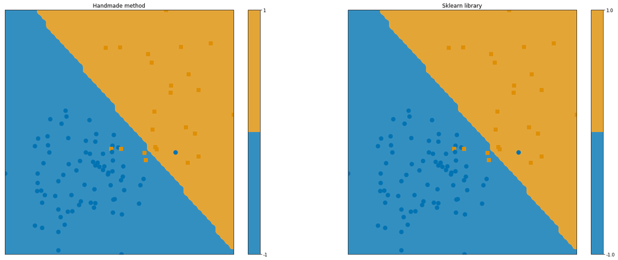

```python
LDAClassifier_test = LDAClassifier()
LDAClassifier_test.fit(X1[::2],y1[::2])
y1_LDAClassifier_pred = LDAClassifier_test.predict(X1[1::2])

def f_LDAClassifier(x):
    return LDAClassifier_test.predict(x)

plt.figure(figsize=(25,10))
plt.subplot(121)
plt.title("Handmade method")
frontiere_new(f_LDAClassifier, X1[1::2],y1[1::2])
pred_error_rate = 1 - LDAClassifier_test.score(X1[1::2],y1[1::2])
print(f"Le taux d'erreur sur les données test avec notre méthode est de {round(100*pred_error_rate,2)} %\n")


######################################
from sklearn.discriminant_analysis import LinearDiscriminantAnalysis


LDA_sklearn_test = LinearDiscriminantAnalysis()
LDA_sklearn_test.fit(X1[::2],y1[::2])
y1_LDA_sklearn_pred = LDA_sklearn_test.predict(X1[1::2])

def f_LDA_sklearn(x):
    return LDA_sklearn_test.predict(x)

plt.subplot(122)
plt.title("Sklearn library")
frontiere_new(f_LDA_sklearn, X1[1::2],y1[1::2])
pred_error_rate_sklearn = 1 - LDA_sklearn_test.score(X1[1::2],y1[1::2])
print(f"Le taux d'erreur sur les données test avec la librairie sklearn est de {round(100*pred_error_rate_sklearn,2)} %\n")
```

> On constate que pour le même jeu de données, les résultats en entraînant sur la moitié du jeu sont légèrement moins bon qu'avec la méthode précédente.

> Voyons ce que nous obtenons pour le jeu de données #3 :

```
Le taux d'erreur sur les données test avec notre méthode est de 14.0 %

Le taux d'erreur sur les données test avec la librairie sklearn est de 14.0 %
```

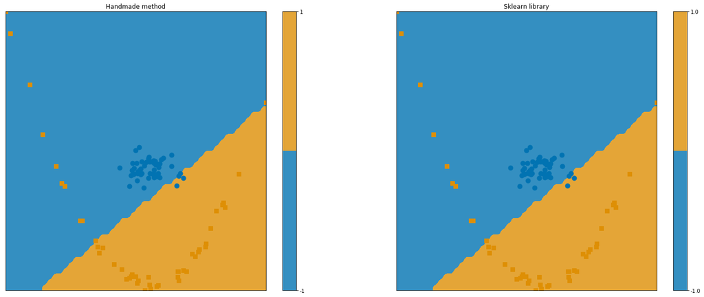

```python
LDAClassifier_test = LDAClassifier()
LDAClassifier_test.fit(X3[::2],y3[::2])
y3_LDAClassifier_pred = LDAClassifier_test.predict(X3[1::2])

def f_LDAClassifier(x):
    return LDAClassifier_test.predict(x)

plt.figure(figsize=(25,10))
plt.subplot(121)
plt.title("Handmade method")
frontiere_new(f_LDAClassifier, X3[1::2],y3[1::2])
pred_error_rate = 1 - LDAClassifier_test.score(X3[1::2],y3[1::2])
print(f"Le taux d'erreur sur les données test avec notre méthode est de {round(100*pred_error_rate,2)} %\n")


######################################
from sklearn.discriminant_analysis import LinearDiscriminantAnalysis


LDA_sklearn_test = LinearDiscriminantAnalysis()
LDA_sklearn_test.fit(X3[::2],y3[::2])
y3_LDA_sklearn_pred = LDA_sklearn_test.predict(X3[1::2])

def f_LDA_sklearn(x):
    return LDA_sklearn_test.predict(x)

plt.subplot(122)
plt.title("Sklearn library")
frontiere_new(f_LDA_sklearn, X3[1::2], y3[1::2])
pred_error_rate_sklearn = 1 - LDA_sklearn_test.score(X3[1::2], y3[1::2])
print(f"Le taux d'erreur sur les données test avec la librairie sklearn est de {round(100*pred_error_rate_sklearn,2)} %\n")
```

```python
knn_test = KNeighborsClassifier(n_neighbors = 20)
knn_test.fit(X1[::2], y1[::2])
error_rate_test = (1 - knn_test.score(X1[1::2], y1[1::2]))*100
print(f"\n Le taux d'erreur sur les données de test du jeu #1 est de {round(error_rate_test,2)} %")
```

```
 Le taux d'erreur sur les données de test du jeu #1 est de 5.0 %
```

## - Régression Logistique -

### Méthode discriminative avec régression logistique

Importer le module `sklearn.linear_model` qui contient en particulier la classe `LogisticRegression` qui nous servira dans la suite.

```python
from sklearn.linear_model import LogisticRegression
```

#### Question 21 : Classification par régression logistique

Appliquez la classification par régression logistique sur les données *rand_bi_gauss*. Comparer les résultats avec la LDA, notamment lorsqu'une classe est beaucoup plus petite que l’autre (a beaucoup moins d’observations). On parle alors de classes déséquilibrées.

> Commençons par observer le cas où les classes sont équilibrées avec 500 observations chacunes :

```python
X1,y1 = rand_bi_gauss(n1=500, n2=500, mu1=[1, 1], mu2=[-1, -1], sigmas1=[0.9, 0.9], sigmas2=[0.9, 0.9])


lda = LinearDiscriminantAnalysis()
lda.fit(X1[::2],y1[::2])
lda.predict(X1[1::2])


log_reg = LogisticRegression(solver='lbfgs', multi_class='multinomial')
log_reg.fit(X1[::2],y1[::2])
y_pred_log_reg = log_reg.predict(X1[1::2])

# Error rates

error_rate_log_reg = 1 - log_reg.score(X1[1::2],y1[1::2])
error_rate_lda = 1 - lda.score(X1[1::2],y1[1::2])

print(f"Le taux d'erreur avec la méthode LDA est de {round(100*error_rate_lda,2)} %")
print(f"Le taux d'erreur avec la régression logistique est {round(100*error_rate_log_reg,2)} %")
```

```
Le taux d'erreur avec la méthode LDA est de 5.8 %
Le taux d'erreur avec la régression logistique est 6.0 %
```

> Quand les classes sont équilibrées, on remarque que les résultats sont à peu près équivalent, parfois la regression logistique est meilleure, parfois la LDA fonctionne mieux, tout dépend de jeux de données initiaux.

> Regardons maintenant le cas où les classes sont déséquilibrées avec une classe à 500 observations et l'autre à 100 :

```python
X1,y1=rand_bi_gauss(n1=500, n2=100, mu1=[1, 1], mu2=[-1, -1], sigmas1=[0.9, 0.9], sigmas2=[0.9, 0.9])

lda = LinearDiscriminantAnalysis()
lda.fit(X1[::2],y1[::2])
lda.predict(X1[1::2])


log_reg = LogisticRegression(solver='lbfgs', multi_class='multinomial')
log_reg.fit(X1[::2],y1[::2])
y_pred_log_reg = log_reg.predict(X1[1::2])

# Error rates

error_rate_log_reg = 1 - log_reg.score(X1[1::2],y1[1::2])
error_rate_lda = 1 - lda.score(X1[1::2],y1[1::2])

print(f"Le taux d'erreur avec la méthode LDA est de {round(100*error_rate_lda,2)} %")
print(f"Le taux d'erreur avec la régression logistique est {round(100*error_rate_log_reg,2)} %")
```

```
Le taux d'erreur avec la méthode LDA est de 2.33 %
Le taux d'erreur avec la régression logistique est 2.67 %
```

> En relançant plusieurs fois les calculs, on constate globalement que le **taux d'erreur est plus faible quand les classes sont déséquilibrées**.

#### Question 22 : Interprétation de variables

À quoi correspond la variable `coef_` du modèle ? Et `intercept_` ?

> La documentation de `sklearn` sur la régression logistique nous donne :
> - **coef_** : array, shape (1, n_features) or (n_classes, n*features) Coefficient of the features in the decision function. coef* is of shape (1, n_features) when the given problem is binary. In particular, when multi*class='multinomial', coef* corresponds to outcome 1 (True) and -coef_ corresponds to outcome 0 (False).
> - **intercept_** : array, shape (1,) or (n_classes,) Intercept (a.k.a. bias) added to the decision function. If fit*intercept is set to False, the intercept is set to zero. intercept* is of shape (1,) when the given problem is binary. In particular, when multi*class='multinomial', intercept* corresponds to outcome 1 (True) and -intercept_ corresponds to outcome 0 (False).

> Ainsi, on peut en comprendre que `coef_` et `intercept_` caractérisent l'hyperplan qui sépare linéairement les différentes classes : $$y = w_{1}x^{T} \ + \ w_{0}$$ où $w_{1}$ est `coef_` et $w_{1}$ `intercept_`.

> Dans notre cas, avec les classes déséquilibrées, nous avons les valeurs suivantes :

```python
print(f"coeff_ vaut {log_reg.coef_}\n")
print(f"intercept_ vaut {log_reg.intercept_}")
```

```
coeff_ vaut [[1.04006169 1.07258988]]

intercept_ vaut [0.91632639]
```

#### Question 23 : Frontière de décision avec les deux classifieurs linéaires

Utiliser la fonction `frontiere_new` pour visualiser la frontière de décision.

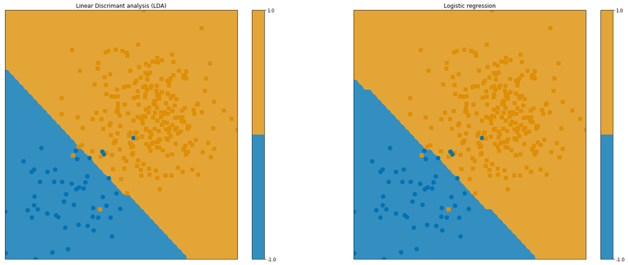

```python
def f_lda(x):
    return lda.predict(x)

def f_log_reg(x):
    return log_reg.predict(x)

plt.figure(figsize=(25,10))

plt.subplot(121)
plt.title("Linear Discrimant analysis (LDA)")
frontiere_new(f_lda, X1[1::2], y1[1::2])

plt.subplot(122)
plt.title("Logistic regression")
frontiere_new(f_log_reg, X1[1::2], y1[1::2])
```

> La **frontière de décision** dans le cas des **classifieurs linéaires** est **quasiment identique**.

#### Question 24 : Application de la régression logistique à la base digits

Appliquez la classification par régression logistique à des données issues de la base digits. Comme précédemment, coupez l’échantillon en deux parties de même taille et utilisez la première partie pour l’apprentissage et la deuxième pour tester. Indiquez le taux d’erreur.

> On reprend les exemples de code donnés avec la base de données :

```
Classification report for classifier LogisticRegression(C=1.0, class_weight=None, dual=False, fit_intercept=True,
                   intercept_scaling=1, l1_ratio=None, max_iter=100,
                   multi_class='multinomial', n_jobs=None, penalty='l2',
                   random_state=None, solver='newton-cg', tol=0.0001, verbose=0,
                   warm_start=False):
              precision    recall  f1-score   support

           0       0.99      0.97      0.98        88
           1       0.96      0.88      0.92        91
           2       0.99      0.98      0.98        86
           3       0.96      0.85      0.90        91
           4       0.98      0.92      0.95        92
           5       0.90      0.96      0.93        91
           6       0.92      0.99      0.95        91
           7       0.97      0.96      0.96        89
           8       0.87      0.89      0.88        88
           9       0.83      0.95      0.88        92

    accuracy                           0.93       899
   macro avg       0.94      0.93      0.93       899
weighted avg       0.94      0.93      0.93       899


--------------------------------------------------------------------------
Le taux d'erreur avec la régression logistique est de 6.79 %
--------------------------------------------------------------------------
```

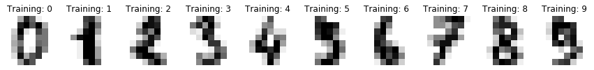

```python
# The digits dataset
digits = datasets.load_digits()

images_and_labels = list(zip(digits.images, digits.target))
plt.figure(figsize = (15,10))

for index, (image, label) in enumerate(images_and_labels[:10]):
    plt.subplot(1, 10, index + 1)
    plt.axis('off')
    plt.imshow(image, cmap=plt.cm.gray_r, interpolation='nearest')
    plt.title('Training: %i' % label)


# To apply a classifier on this data, we need to flatten the image, to
# turn the data in a (samples, feature) matrix :
n_samples = len(digits.images)
data = digits.images.reshape((n_samples, -1))

# Create a classifier: Logistic Regression
classifier = LogisticRegression(solver='newton-cg', multi_class='multinomial')

# We learn the digits on the first half of the digits
classifier.fit(data[:n_samples // 2], digits.target[:n_samples // 2])

# Now predict the value of the digit on the second half :
expected = digits.target[n_samples // 2:]
predicted = classifier.predict(data[n_samples // 2:])


print("Classification report for classifier %s:\n%s\n"
      % (classifier, metrics.classification_report(expected, predicted)))
print('--------------------------------------------------------------------------')
print(f"Le taux d'erreur avec la régression logistique est de {round(100*(1 - metrics.accuracy_score(expected, predicted)),2)} %")
print('--------------------------------------------------------------------------')
```

> Affichons les tests de prédiction :

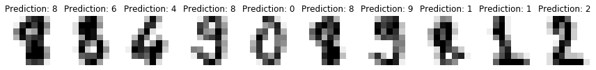

```python
images_and_predictions = list(zip(digits.images[n_samples // 2:], predicted))
plt.figure(figsize = (15,10))

for index, (image, prediction) in enumerate(images_and_predictions[:10]):
    plt.subplot(1, 10, index + 1)
    plt.axis('off')
    plt.imshow(image, cmap=plt.cm.gray_r, interpolation='nearest')
    plt.title('Prediction: %i' % prediction)

plt.show()
```

## Conclusion du TP :

> Dans ce TP, nous avons vu différents classifieurs :
> - Le **KNN** : classifieur non linéaire permettant de classifier efficacement des données non linéairement séparables.
> - Le **Logistic regression** et **LDA** : classifieurs linéaires permettant de séparer efficacement des données linérairement séparables. Le LDA possède des hypothèses plus forte que la régression logistique (hypothèse de gaussianité que la régression logistique n'a pas).

> Nous avons vu dans le cas du classifieur **KNN** comment trouver son hyperparamètre optimal avec une cross validation.

> Nous avons constaté qu'un modèle est optimal lorsqu'il n'est pas trop complexe.